# Reproducible Research Course Project 1

Taylor P

March 17, 2018

## Reproducible Research Course Project 1 (“PA1_template.Rmd”)

### Introduction

This assignment makes use of data from a personal activity monitoring device. This device collects data at 5 minute intervals through out the day. The data consists of two months of data from an anonymous individual collected during the months of October and November, 2012 and include the number of steps taken in 5 minute intervals each day (coursera.com). This assignment will analze the data with the methods outlined in the Methods section.

### Methods

The steps of this analysis are:

1. Load and preprocess the data
2. Calculate mean total number of steps taken per day
3. Determine the average daily activity pattern
4. Impute missing values
5. Determine whether there are differences in activity patterns between weekdays and weekends

### Step 1: Load and Preprocess the Data

This steps downloads the data from the link in the assignment and unzips the file if it has not been done before. Then, the file is read into memory and the date column is converted to date objects. The data frame is then converted to a data table for subsetting rows.

```r
library(data.table)
filename <- "activity_data.zip"
## Check if file exists and download the dataset if it hasn't
if (!file.exists(filename)){
  file_url <- "https://d396qusza40orc.cloudfront.net/repdata%2Fdata%2Factivity.zip"
  download.file(file_url, filename, method="auto")
}
## Check if the file has been unzipped and unzip it if it hasn't
fp <- "activity.csv"
if (!file.exists(fp)){
  unzip(filename)
}
## Read in the data and convert it to a data.table
df <- read.csv(file=fp, header=TRUE, sep=",", na.strings="NA")
dt <- as.data.table(df)
## Convert date to a date object
dt$date <- as.Date(dt$date)
## Remove NA values and store in a new data table
no_na_dt <- na.omit(dt, col="steps")
```

### Step 2: Calculate Mean and Median Steps Per Day

First, the total number of steps taken per day is summed. The values are plotted in a histogram to display the frequency of each bin. The mean and median values are then calculated.

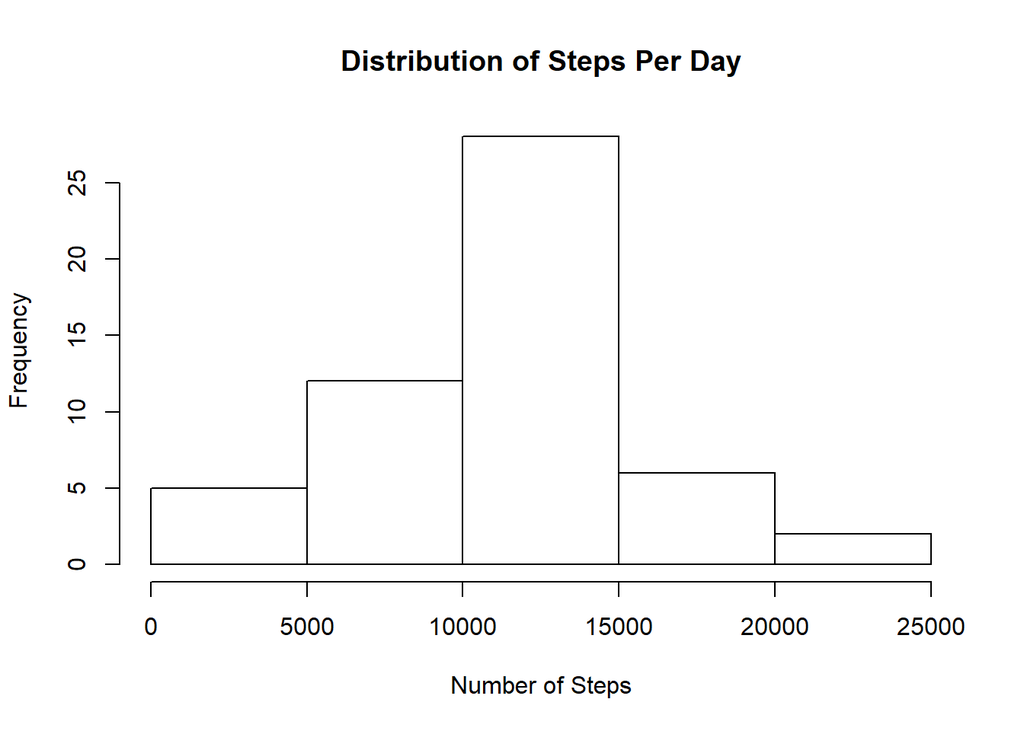

```r
## Subset total steps per day from data table for total steps per day
steps_per_day <- no_na_dt[, sum(steps), by=.(date)]
## Plot a histogram of the data
hist(steps_per_day$V1,
     main="Distribution of Steps Per Day",
     xlab="Number of Steps")
```

```r
## Calculate the mean
mean_steps <- mean(steps_per_day$V1)
print(mean_steps)
```

```
## [1] 10766.19
```

```r
## Calculate the median
median_steps <- median(steps_per_day$V1)
print(median_steps)
```

```
## [1] 10765
```

From the total steps per day, the mean was found to be 10766.19 and the median was found to be 10765

### Step 3: Determine the Average Daily Activity Pattern

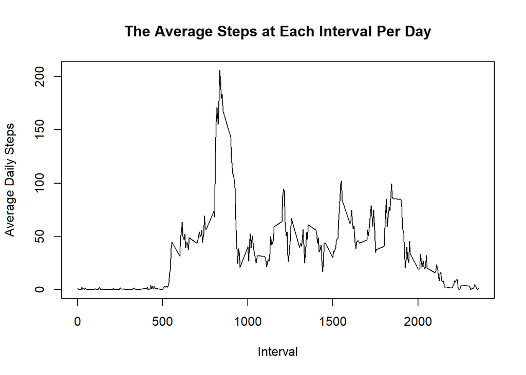

```r
#obtain the average steps per interval
avg_daily_steps <- no_na_dt[, mean(steps), by=.(interval)]
#Plot a line plot of the average steps per interval
plot(avg_daily_steps$V1 ~ avg_daily_steps$interval,
     pch=16,
     xlab="Interval",
     ylab="Average Daily Steps",
     main="The Average Steps at Each Interval Per Day",
     type="l")
```

```r
#subset the interval containing the max number of average steps
max_steps <- avg_daily_steps[which(avg_daily_steps$V1 == max(avg_daily_steps$V1)),]
print(max_steps$interval)
```

```
## [1] 835
```

```r
print(max_steps$V1)
```

```
## [1] 206.1698
```

##### Which 5-minute interval, on average across all the days in the dataset, contains the maximum number of steps?

The average 5-minute interval contining the maximum number of steps was 835 with an average number of steps equal to 206.1698113.

### Step 4: Impute missing values

There are a number of days/intervals where there are missing values (i.e. NA). These values will be imputed to determine if the presence of missing days may introduce bias into some calculations or summaries of the data.

#### Step 4-1: Calculate and report the total number of missing values in the dataset (i.e. the total number of rows with NAs)

```r
# count ant print the total number of missing values in this data set. In this
# case, missing values are only in the steps column.
missing_vals <- table(is.na(dt))
print(missing_vals)
```

```
##
## FALSE  TRUE
## 50400  2304
```

There are a total of 2304 missing values in this data set (4.37%).

#### Step 4-2: Devise a strategy for filling in the missing values

The strategy chosen to impute the missing values was to take the rounded mean for the interval that is missing a value.

```r
#subset all rows missing a value in steps
nas <- is.na(dt$steps)
missing_no <- dt[nas,]
#add a column to the missing data to hold the imputed value
missing_no[,imputed:=numeric()]
#loop over each missing value and take the rounded number of steps from the
#same interval of the previously found average daily steps (Step 3)
for (i in 1:length(missing_no$steps)) {
  holder <- match(missing_no[i,3], avg_daily_steps$interval)
  avg_value <- avg_daily_steps[holder,2]
  rounded_avg_value <- round(avg_value, 0)
  missing_no[i, 4] = rounded_avg_value
}
```

#### Step 4-3: Create a new dataset that is equal to the original dataset but with the missing data filled in

The imputed values were then added to the complete observations subsetted in Step 1

```r
#combine the imputed values with the complete observations
imputed_data <- subset(missing_no, select=c("imputed", "date", "interval"))
setnames(imputed_data, "imputed", "steps")
full_dt <- rbind(imputed_data, no_na_dt)
```

#### Step 4-4: Recalculate Mean and Median Steps Per Day

A histogram of the total number of steps taken each day was plotted and the mean and median total number of steps taken per day was calculated.

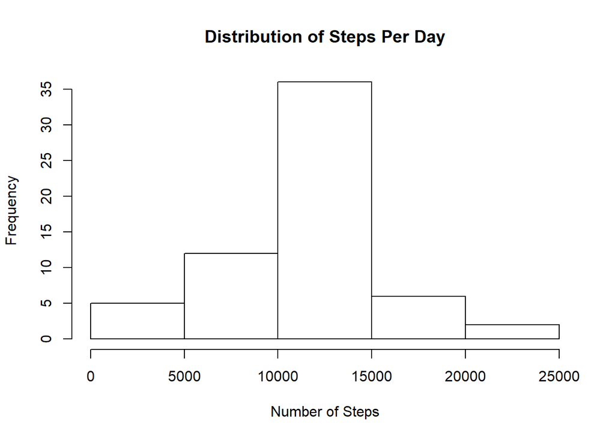

```r
## Subset total steps per day from data table for total steps per day
steps_per_day <- full_dt[, sum(steps), by=.(date)]
## Plot a histogram of the data
hist(steps_per_day$V1,
     main="Distribution of Steps Per Day",
     xlab="Number of Steps")
```

```r
## Calculate the mean
imputed_mean_steps <- mean(steps_per_day$V1)
print(mean_steps)
```

```
## [1] 10766.19
```

```r
## Calculate the median
imputed_median_steps <- median(steps_per_day$V1)
print(imputed_median_steps)
```

```
## [1] 10762
```

## Step 5: Determine if There are any Differences in Activity Patterns Between Weekdays and Weekends

```r
#Determine which day of the week each date occurs on
full_dt$day.of.week <- weekdays(full_dt$date)
#If the day of the week is a saturday or sunday label that as a weekend, otherwise label as a weekday
full_dt$day <- full_dt[, ifelse(full_dt$day.of.week=="Saturday" | full_dt$day.of.week=="Sunday", "weekend", "weekday")]
#Remove the day.of.week column
full_dt[,day.of.week:=NULL]
#dispaly the first few rows of the data
print(head(full_dt))
```

```
##    steps       date interval     day
## 1:     2 2012-10-01        0 weekday
## 2:     0 2012-10-01        5 weekday
## 3:     0 2012-10-01       10 weekday
## 4:     0 2012-10-01       15 weekday
## 5:     0 2012-10-01       20 weekday
## 6:     2 2012-10-01       25 weekday
```

A panel plot containing a time series plot of the 5-minute interval (x-axis) and the average number of steps taken, averaged across all weekday days or weekend days (y-axis) was plotted.

[figure not shown]

```r
#Subset the weekends and weekdays
SatSun <- full_dt[day=="weekend", mean(steps), by=.(interval)]
MTWThF <- full_dt[day=="weekday", mean(steps), by=.(interval)]
#Set parameters for the panel plot
par(mfrow=c(2, 1), oma = c(5,4,0,0) + 0.1, mar = c(2,2,0.3,0) + 0.1)
#Create the first plot of the Weekend average steps per interval
plot.new()
plot.window(xlim=c(min(MTWThF$interval, SatSun$interval),
                   2500),
            ylim=c(min(MTWThF$V1, SatSun$V1),
                   250))
lines(SatSun$V1 ~ SatSun$interval,
     col="blue")
axis(side=1, tick=TRUE, pos=0)
axis(side=2, tick=TRUE, pos=0)
title(main="Weekend", line=-1, font.main=1)
title(xlab="Interval", ylab="Number of Steps", line=1)
#Create the second plot of the Weekend average steps per interval
plot.new()
plot.window(xlim=c(min(MTWThF$interval, SatSun$interval),
                   2500),
            ylim=c(min(MTWThF$V1, SatSun$V1),
                   250))
lines(MTWThF$V1 ~ MTWThF$interval,
     col="blue")
axis(side=1, tick=TRUE, pos=0)
axis(side=2, tick=TRUE, pos=0)
title(main="Weekend", line=-1, font.main=1)
title(xlab="Interval", ylab="Number of Steps", line=1)
```

The main difference between weekends and weekdays is that weekdays typically start with a higher spike in total steps followed by a a period of lower total steps when compared to weekends. Weekends have a high spike early in the day, but is then followed with prolonged intervals of higher steps when compared to weekdays.